# 收集

##### test3

```python
archive_clean.rating_numerator.value_counts()
```

```
12.00      451
10.00      417
11.00      393
13.00      262
9.00       151
8.00       101
7.00        52
14.00       36
6.00        34
5.00        30
3.00        19
4.00        15
2.00         9
1.00         4
60.00        1
84.00        1
99.00        1
1776.00      1
13.50        1
11.27        1
165.00       1
11.26        1
0.00         1
9.75         1
45.00        1
88.00        1
144.00       1
44.00        1
121.00       1
204.00       1
80.00        1
143.00       1
Name: rating_numerator, dtype: int64
```

```python
archive_clean.rating_denominator.value_counts()
```

```
10.0     1980
50.0        2
80.0        2
130.0       1
150.0       1
120.0       1
110.0       1
40.0        1
90.0        1
170.0       1
70.0        1
Name: rating_denominator, dtype: int64
```

```python
archive_clean.info()
```

```
<class 'pandas.core.frame.DataFrame'>
Int64Index: 1992 entries, 0 to 2355
Data columns (total 11 columns):
tweet_id              1992 non-null int64
timestamp             1992 non-null datetime64[ns]
source                1992 non-null object
text                  1992 non-null object
expanded_urls         1992 non-null object
rating_numerator      1992 non-null float64
rating_denominator    1992 non-null float64
name                  1992 non-null object
retweet_count         1992 non-null float64
favorite_count        1992 non-null float64
stage                 368 non-null object
dtypes: datetime64[ns](1), float64(4), int64(1), object(5)
memory usage: 266.8+ KB
```

#### 狗狗的名字需要修正

##### define

**step1:提取name**

*正则表达式*

- 狗狗只有名，没有姓
  - 也就是说，只需要匹配一个名即可
  - 大写开头
  - 前面有特定语句搭配，引出狗狗name
    - *这里我只考虑以下几种匹配情况*
      - 只有一个名字
        - This is dog_name
        - H/his name is dog_name
        - H/her name is dog_name
        - Meet dog_name
        - Say hello to dog_name
        - named dog_name
        - ...
      - 不止一个名字，这里我默认为两个名字
        - This is dog_name1 and dog_name2
        - Meet dog_name1 and dog_name2
        - Say hello to dog_name1 and dog_name2
        - Here we have dog_name1 and dog_name2
        - ...

*怎么提取狗狗名字*

- 按照上述规律编写好正则表达式
  - 我将以上三类合并为 空格 + is + 空格 + dog_name(大写开头)
    - This is dog_name
    - H/his name is dog_name
    - H/her name is dog_name
  - 另外，我发现狗狗的名字中有时会出现带有变音符号的字母
    - 比如index = 1559 对应的狗狗名字 Frönq
    - 这里需要使用 \w 来匹配余下部分，同时flags=re.U
- 对 archive_clean.text 使用 extract，提取狗狗名字

**step2:合并name**

- 对于不止一个狗狗名字的行来说，会找到2个狗狗名字，将这两个狗狗名字合并至一个单元格内，使用逗号间隔符分开
  - （这里我按照以上规律所写的正则表达式最多只能匹配到2个狗狗名字）
  - *怎么合并？*
    - 类似 df.name1.map(str) + ',' + df.name2.map(str)
    - 如果name2 为np.nan,那么合并后，使用 replace('nan',''),再使用strip(',')即可去掉多余逗号
    - 再填充为空的单元格，使用 np.where(name,name,np.nan)

```python
# 筛选特定word,来发现狗狗名字的出现规律
word = 'Oliver'
print(archive_clean.text[archive_clean.text.str.contains(word)])
len(archive_clean.text[archive_clean.text.str.contains(word)])
```

```
15      This is Oliver. You're witnessing one of his m...
178     This is Oscar and Oliver. Oliver shrunk Oscar....
301     Say hello to Oliver. He's pretty exotic. Fairl...
439     This is Oliver. He has dreams of being a servi...
916     This is Oliver. He's an English Creamschnitzel...
1034    This is Oliver. He's downright gorgeous as hel...
1168    This is Oliver. Bath time is upon him. His fea...
1287    This is Oliver. That is his castle. He protect...
1318    This is Oliver (pronounced "Ricardo"). He's a ...
1411    This is Oliver. He does toe touches in his sle...
1876    Say hello to Oliver. He thought what was insid...
2237    This lil pup is Oliver. Hops around. Has wings...
Name: text, dtype: object
```

```
12
```

```python
# index = 1559 对应的狗狗名字为 Frönq ，带有变音符号
archive_clean.text[1559]
```

```
'This is Frönq. He got caught stealing a waffle. Damn it Frönq. 9/10 https://t.co/7ycWCUrjmZ'
```

##### code

```python
pattern = r'(?:(?:[Mm]eet|[Ss]ay hello to|[Hh]ere we have|named|\sis)\s([A-Z]\w+)(?:\sand\s([A-Z]\w+))?)'
df_names = archive_clean.text.str.extract(pattern, expand=True, flags=re.U)
names = df_names[0].map(str) + ',' + df_names[1].map(str)

archive_clean['names'] = names.str.replace('nan','').str.strip(',')
archive_clean['names'] = np.where(archive_clean['names'],archive_clean['names'],np.nan)

archive_clean.drop('name', axis=1, inplace=True)
```

##### test

```python
archive_clean.names.value_counts()
```

```
Charlie           11
Oliver            11
Cooper            10
Penny              9
Tucker             9
Lucy               9
Winston            8
Sadie              7
Lola               7
Daisy              7
Toby               7
Jax                6
Koda               6
Bella              6
Stanley            6
Buddy              5
Bo                 5
Dave               5
Rusty              5
Leo                5
Louis              5
Scout              5
Chester            5
Zoey               5
Bailey             5
Jerry              4
Milo               4
Dexter             4
Duke               4
Chip               4
                  ..
Cleopatricia       1
Brooks             1
Bodie              1
Hank,Sully         1
Trevith            1
Toffee             1
Ozzy               1
Brutus,Jersey      1
Mya                1
Oakley,Charlie     1
Wafer              1
Poppy              1
Covach             1
Hanz               1
Marlee             1
Pippin             1
Creg               1
River              1
Bobb               1
Jackie             1
Kaia               1
Danny              1
Dunkin             1
Maks               1
Halo               1
Alphred            1
Snicku             1
Randall            1
Ruffles            1
Zara               1
Name: names, Length: 953, dtype: int64
```

```python
archive_clean.info()
```

```
<class 'pandas.core.frame.DataFrame'>
Int64Index: 1992 entries, 0 to 2355
Data columns (total 11 columns):
tweet_id              1992 non-null int64
timestamp             1992 non-null datetime64[ns]
source                1992 non-null object
text                  1992 non-null object
expanded_urls         1992 non-null object
rating_numerator      1992 non-null float64
rating_denominator    1992 non-null float64
retweet_count         1992 non-null float64
favorite_count        1992 non-null float64
stage                 368 non-null object
names                 1385 non-null object
dtypes: datetime64[ns](1), float64(4), int64(1), object(5)
memory usage: 266.8+ KB
```

### 整洁度

#### 狗狗地位合并为一列

已经在前面（狗狗地位列数据单元格重新整理）处理完成

## predications

### 质量

```python
predications_clean.head(5)
```

|  | tweet_id | jpg_url | img_num | p1 | p1_conf | p1_dog | p2 | p2_conf | p2_dog | p3 | p3_conf | p3_dog |
| --- | --- | --- | --- | --- | --- | --- | --- | --- | --- | --- | --- | --- |
| 0 | 666020888022790149 | https://pbs.twimg.com/media/CT4udn0WwAA0aMy.jpg | 1 | Welsh_springer_spaniel | 0.465074 | True | collie | 0.156665 | True | Shetland_sheepdog | 0.061428 | True |
| 1 | 666029285002620928 | https://pbs.twimg.com/media/CT42GRgUYAA5iDo.jpg | 1 | redbone | 0.506826 | True | miniature_pinscher | 0.074192 | True | Rhodesian_ridgeback | 0.072010 | True |
| 2 | 666033412701032449 | https://pbs.twimg.com/media/CT4521TWwAEvMyu.jpg | 1 | German_shepherd | 0.596461 | True | malinois | 0.138584 | True | bloodhound | 0.116197 | True |
| 3 | 666044226329800704 | https://pbs.twimg.com/media/CT5Dr8HUEAA-lEu.jpg | 1 | Rhodesian_ridgeback | 0.408143 | True | redbone | 0.360687 | True | miniature_pinscher | 0.222752 | True |
| 4 | 666049248165822465 | https://pbs.twimg.com/media/CT5IQmsXIAAKY4A.jpg | 1 | miniature_pinscher | 0.560311 | True | Rottweiler | 0.243682 | True | Doberman | 0.154629 | True |

#### p1,p2,p3 对应的单元格内预测的种类大小写不一致

##### define

将p1,p2,p3 单元格内的值，每个单词首字母全改为大写，使用str.title() 即可完成

##### code

```python
for column in ('p1 p2 p3').split():
    predications_clean[column] = predications_clean[column].str.title()
```

##### test

```python
 predications_clean[('p1 p2 p3').split()].head(10)
```

|  | p1 | p2 | p3 |
| --- | --- | --- | --- |
| 0 | Welsh_Springer_Spaniel | Collie | Shetland_Sheepdog |
| 1 | Redbone | Miniature_Pinscher | Rhodesian_Ridgeback |
| 2 | German_Shepherd | Malinois | Bloodhound |
| 3 | Rhodesian_Ridgeback | Redbone | Miniature_Pinscher |
| 4 | Miniature_Pinscher | Rottweiler | Doberman |
| 5 | Bernese_Mountain_Dog | English_Springer | Greater_Swiss_Mountain_Dog |
| 6 | Box_Turtle | Mud_Turtle | Terrapin |
| 7 | Chow | Tibetan_Mastiff | Fur_Coat |
| 8 | Shopping_Cart | Shopping_Basket | Golden_Retriever |
| 9 | Miniature_Poodle | Komondor | Soft-Coated_Wheaten_Terrier |

### 整洁度

#### 将预测结果数据合并至archive中

##### define

预测表格（predications），其中包含了预测结果的前三名，推特 ID，图像 url 以及最可信的预测结果对应的图像编号

这里由于预测可信概率是排序好的，即某一行数据中，p1_conf > p2_conf > p3_conf

那么我这里会作一个狗狗预测的筛选结果添加至archive中

- 假定此为该 tweet_id 对应的图片中的狗狗种类

**如何筛选？**

- 先看排名第一的预测结果，如果其中的判断是否是狗为真（True），那么我会将此记下，如果第一预测结果不为狗狗，那么再看第二预测结果，以此类推
- 如果三个预测对应的狗狗预测全为False，那么，将此行数据对应记为，未识别出狗狗

注意：这里需要创建的列（之后将此创建的数据合并至 archive 中）

- 预测的狗狗种类，使用*type*表示
- 预测的可信概率，使用*conf*表示

**我想要合并的方式**

- (p1_dog,p2_dog,p3_dog) 合并为 *isdog*
  - 若为 True ，使用 1 指代
  - 若为 False，使用 0 指代
    - 例：结构格式为 101
    - 表示 p1_dog=True, p2_dog=False, p3_dog=True
- (p1_conf,p2_conf,p3_conf) 合并为*conf*
- (p1,p2,p3) 合并为*type*

**如何将预测结果添加至 archive_clean中？**

- 使用pd.merge(archive_clean,pre_df,on='tweet_id',how='left')

##### code

```python
pre_backup = predications_clean.copy(deep=True)

# 置换True为1，False为0
pre_backup.replace({True:1,False:0},inplace=True)
```

```python
pre_backup['isdog'] = pre_backup.p1_dog.astype(str) + pre_backup.p2_dog.astype(str) + pre_backup.p3_dog.astype(str)
# pre_backup['isdog'] = pre_backup.p1_dog.map(str) + pre_backup.p2_dog.map(str) + pre_backup.p3_dog.map(str)
pre_backup['conf'] = pre_backup.p1_conf.astype(str) + ','+ pre_backup.p2_conf.astype(str) + ','+ pre_backup.p3_conf.astype(str)
pre_backup['type'] = pre_backup.p1.astype(str) + ','+ pre_backup.p2.astype(str)+ ','+ pre_backup.p3.astype(str)
pre_backup.head()
```

|  | tweet_id | jpg_url | img_num | p1 | p1_conf | p1_dog | p2 | p2_conf | p2_dog | p3 | p3_conf | p3_dog | isdog | conf | type |
| --- | --- | --- | --- | --- | --- | --- | --- | --- | --- | --- | --- | --- | --- | --- | --- |
| 0 | 666020888022790149 | https://pbs.twimg.com/media/CT4udn0WwAA0aMy.jpg | 1 | Welsh_Springer_Spaniel | 0.465074 | 1 | Collie | 0.156665 | 1 | Shetland_Sheepdog | 0.061428 | 1 | 111 | 0.465074,0.156665,0.0614285 | Welsh_Springer_Spaniel,Collie,Shetland_Sheepdog |
| 1 | 666029285002620928 | https://pbs.twimg.com/media/CT42GRgUYAA5iDo.jpg | 1 | Redbone | 0.506826 | 1 | Miniature_Pinscher | 0.074192 | 1 | Rhodesian_Ridgeback | 0.072010 | 1 | 111 | 0.506826,0.0741917,0.07201 | Redbone,Miniature_Pinscher,Rhodesian_Ridgeback |
| 2 | 666033412701032449 | https://pbs.twimg.com/media/CT4521TWwAEvMyu.jpg | 1 | German_Shepherd | 0.596461 | 1 | Malinois | 0.138584 | 1 | Bloodhound | 0.116197 | 1 | 111 | 0.596461,0.138584,0.116197 | German_Shepherd,Malinois,Bloodhound |
| 3 | 666044226329800704 | https://pbs.twimg.com/media/CT5Dr8HUEAA-lEu.jpg | 1 | Rhodesian_Ridgeback | 0.408143 | 1 | Redbone | 0.360687 | 1 | Miniature_Pinscher | 0.222752 | 1 | 111 | 0.408143,0.360687,0.222752 | Rhodesian_Ridgeback,Redbone,Miniature_Pinscher |
| 4 | 666049248165822465 | https://pbs.twimg.com/media/CT5IQmsXIAAKY4A.jpg | 1 | Miniature_Pinscher | 0.560311 | 1 | Rottweiler | 0.243682 | 1 | Doberman | 0.154629 | 1 | 111 | 0.560311,0.243682,0.154629 | Miniature_Pinscher,Rottweiler,Doberman |

```python
# 构造confidence,dog_type列数据
confidence = []
dog_type =[]
for i in range(pre_backup.shape[0]):
    x = pre_backup.iloc[i].isdog.find('1')
    if x!= -1:
        confidence.append(pre_backup.iloc[i].conf.split(',')[x])
        dog_type.append(pre_backup.iloc[i].type.split(',')[x])
    else:
        confidence.append(0)
        dog_type.append('NotFound')
```

```python
id_type_conf = pd.DataFrame({'tweet_id':pre_backup.tweet_id,
                             'jpg_url':pre_backup.jpg_url,
                             'img_num':pre_backup.img_num,
                             'dog_type':dog_type,
                             'confidence':confidence},
                             columns = ['tweet_id','jpg_url','img_num','dog_type','confidence',])
id_type_conf.confidence = id_type_conf.confidence.astype(float)

# 合并
archive_clean = pd.merge(archive_clean, id_type_conf,on='tweet_id',how='left')

# 丢弃pre_backup中的p1,p1_conf,p1_dog,p2,p2_conf,p2_dog,p3,p3_conf,p3_dog 列
# 用另一种方式选取列也可达到丢弃列效果
pre_backup = pre_backup[['tweet_id','jpg_url','img_num','isdog','conf','type']]
```

##### test

```python
pre_backup.info()
```

```
<class 'pandas.core.frame.DataFrame'>
RangeIndex: 2075 entries, 0 to 2074
Data columns (total 6 columns):
tweet_id    2075 non-null int64
jpg_url     2075 non-null object
img_num     2075 non-null int64
isdog       2075 non-null object
conf        2075 non-null object
type        2075 non-null object
dtypes: int64(2), object(4)
memory usage: 97.3+ KB
```

```python
pre_backup.head()
```

|  | tweet_id | jpg_url | img_num | isdog | conf | type |
| --- | --- | --- | --- | --- | --- | --- |
| 0 | 666020888022790149 | https://pbs.twimg.com/media/CT4udn0WwAA0aMy.jpg | 1 | 111 | 0.465074,0.156665,0.0614285 | Welsh_Springer_Spaniel,Collie,Shetland_Sheepdog |
| 1 | 666029285002620928 | https://pbs.twimg.com/media/CT42GRgUYAA5iDo.jpg | 1 | 111 | 0.506826,0.0741917,0.07201 | Redbone,Miniature_Pinscher,Rhodesian_Ridgeback |
| 2 | 666033412701032449 | https://pbs.twimg.com/media/CT4521TWwAEvMyu.jpg | 1 | 111 | 0.596461,0.138584,0.116197 | German_Shepherd,Malinois,Bloodhound |
| 3 | 666044226329800704 | https://pbs.twimg.com/media/CT5Dr8HUEAA-lEu.jpg | 1 | 111 | 0.408143,0.360687,0.222752 | Rhodesian_Ridgeback,Redbone,Miniature_Pinscher |
| 4 | 666049248165822465 | https://pbs.twimg.com/media/CT5IQmsXIAAKY4A.jpg | 1 | 111 | 0.560311,0.243682,0.154629 | Miniature_Pinscher,Rottweiler,Doberman |

```python
archive_clean.info()
```

```
<class 'pandas.core.frame.DataFrame'>
Int64Index: 1992 entries, 0 to 1991
Data columns (total 15 columns):
tweet_id              1992 non-null int64
timestamp             1992 non-null datetime64[ns]
source                1992 non-null object
text                  1992 non-null object
expanded_urls         1992 non-null object
rating_numerator      1992 non-null float64
rating_denominator    1992 non-null float64
retweet_count         1992 non-null float64
favorite_count        1992 non-null float64
stage                 368 non-null object
names                 1385 non-null object
jpg_url               1992 non-null object
img_num               1992 non-null int64
dog_type              1992 non-null object
confidence            1992 non-null float64
dtypes: datetime64[ns](1), float64(5), int64(2), object(7)
memory usage: 249.0+ KB
```

```python
archive_clean.head(3)
```

|  | tweet_id | timestamp | source | text | expanded_urls | rating_numerator | rating_denominator | retweet_count | favorite_count | stage | names | jpg_url | img_num | dog_type | confidence |
| --- | --- | --- | --- | --- | --- | --- | --- | --- | --- | --- | --- | --- | --- | --- | --- |
| 0 | 892420643555336193 | 2017-08-01 16:23:56 | Twitter for iPhone | This is Phineas. He's a mystical boy. Only eve... | https://twitter.com/dog_rates/status/892420643... | 13.0 | 10.0 | 8842.0 | 39492.0 | NaN | Phineas | https://pbs.twimg.com/media/DGKD1-bXoAAIAUK.jpg | 1 | NotFound | 0.000000 |
| 1 | 892177421306343426 | 2017-08-01 00:17:27 | Twitter for iPhone | This is Tilly. She's just checking pup on you.... | https://twitter.com/dog_rates/status/892177421... | 13.0 | 10.0 | 6480.0 | 33786.0 | NaN | Tilly | https://pbs.twimg.com/media/DGGmoV4XsAAUL6n.jpg | 1 | Chihuahua | 0.323581 |
| 2 | 891815181378084864 | 2017-07-31 00:18:03 | Twitter for iPhone | This is Archie. He is a rare Norwegian Pouncin... | https://twitter.com/dog_rates/status/891815181... | 12.0 | 10.0 | 4301.0 | 25445.0 | NaN | Archie | https://pbs.twimg.com/media/DGBdLU1WsAANxJ9.jpg | 1 | Chihuahua | 0.716012 |

#### 精简predications

##### define

- 精简工作已经在上一步 *将预测结果数据合并至archive中* 中完成了
- 可能某些人喜欢精简后的数据结构方式,（比如便于处理数据）,但是也有可能某些人可能更喜欢原来的数据结构方式（比如看起来更舒服）
  - 这里我选择保留预测表格的两种结构展示方式 *pre_backup* 和 *predications_clean*
  - 同时 *predications_condense* 保存 *pre_backup* 数据

##### code

```python
predications_condense = pre_backup.copy(deep=True)
```

##### test

```python
predications_condense.head()
```

|  | tweet_id | jpg_url | img_num | isdog | conf | type |
| --- | --- | --- | --- | --- | --- | --- |
| 0 | 666020888022790149 | https://pbs.twimg.com/media/CT4udn0WwAA0aMy.jpg | 1 | 111 | 0.465074,0.156665,0.0614285 | Welsh_Springer_Spaniel,Collie,Shetland_Sheepdog |
| 1 | 666029285002620928 | https://pbs.twimg.com/media/CT42GRgUYAA5iDo.jpg | 1 | 111 | 0.506826,0.0741917,0.07201 | Redbone,Miniature_Pinscher,Rhodesian_Ridgeback |
| 2 | 666033412701032449 | https://pbs.twimg.com/media/CT4521TWwAEvMyu.jpg | 1 | 111 | 0.596461,0.138584,0.116197 | German_Shepherd,Malinois,Bloodhound |
| 3 | 666044226329800704 | https://pbs.twimg.com/media/CT5Dr8HUEAA-lEu.jpg | 1 | 111 | 0.408143,0.360687,0.222752 | Rhodesian_Ridgeback,Redbone,Miniature_Pinscher |
| 4 | 666049248165822465 | https://pbs.twimg.com/media/CT5IQmsXIAAKY4A.jpg | 1 | 111 | 0.560311,0.243682,0.154629 | Miniature_Pinscher,Rottweiler,Doberman |

```python
all(predications_condense == pre_backup)
```

```
True
```

# 存储

```python
archive_file = 'twitter_archive_master.csv'
pre_condense_file = 'image_predications_condense.csv'

archive_clean.to_csv(archive_file,encoding='utf-8',index=False)
predications_condense.to_csv(pre_condense_file,encoding='utf-8',index=False)
```

```python
archive_master = pd.read_csv(archive_file)
image_pre = pd.read_csv(pre_condense_file)
```

```python
archive_master.head(3)
```

|  | tweet_id | timestamp | source | text | expanded_urls | rating_numerator | rating_denominator | retweet_count | favorite_count | stage | names | jpg_url | img_num | dog_type | confidence |
| --- | --- | --- | --- | --- | --- | --- | --- | --- | --- | --- | --- | --- | --- | --- | --- |
| 0 | 892420643555336193 | 2017-08-01 16:23:56 | Twitter for iPhone | This is Phineas. He's a mystical boy. Only eve... | https://twitter.com/dog_rates/status/892420643... | 13.0 | 10.0 | 8842.0 | 39492.0 | NaN | Phineas | https://pbs.twimg.com/media/DGKD1-bXoAAIAUK.jpg | 1 | NotFound | 0.000000 |
| 1 | 892177421306343426 | 2017-08-01 00:17:27 | Twitter for iPhone | This is Tilly. She's just checking pup on you.... | https://twitter.com/dog_rates/status/892177421... | 13.0 | 10.0 | 6480.0 | 33786.0 | NaN | Tilly | https://pbs.twimg.com/media/DGGmoV4XsAAUL6n.jpg | 1 | Chihuahua | 0.323581 |
| 2 | 891815181378084864 | 2017-07-31 00:18:03 | Twitter for iPhone | This is Archie. He is a rare Norwegian Pouncin... | https://twitter.com/dog_rates/status/891815181... | 12.0 | 10.0 | 4301.0 | 25445.0 | NaN | Archie | https://pbs.twimg.com/media/DGBdLU1WsAANxJ9.jpg | 1 | Chihuahua | 0.716012 |

```python
image_pre.head(3)
```

|  | tweet_id | jpg_url | img_num | isdog | conf | type |
| --- | --- | --- | --- | --- | --- | --- |
| 0 | 666020888022790149 | https://pbs.twimg.com/media/CT4udn0WwAA0aMy.jpg | 1 | 111 | 0.465074,0.156665,0.0614285 | Welsh_Springer_Spaniel,Collie,Shetland_Sheepdog |
| 1 | 666029285002620928 | https://pbs.twimg.com/media/CT42GRgUYAA5iDo.jpg | 1 | 111 | 0.506826,0.0741917,0.07201 | Redbone,Miniature_Pinscher,Rhodesian_Ridgeback |
| 2 | 666033412701032449 | https://pbs.twimg.com/media/CT4521TWwAEvMyu.jpg | 1 | 111 | 0.596461,0.138584,0.116197 | German_Shepherd,Malinois,Bloodhound |

# 数据探索分析

申明：

- 以下内容中，**推主**：指代的是WeRateDogs的户主

## 提出问题

```python
# 备份数据
df_archive = archive_master.copy(deep=True)
```

```python
# 这里存在缺失值
# 我并不打算处理，因为缺失值对我后面涉及的分析并没有产生一些干扰，先暂时放着
df_archive.info()
```

```
<class 'pandas.core.frame.DataFrame'>
RangeIndex: 1992 entries, 0 to 1991
Data columns (total 15 columns):
tweet_id              1992 non-null int64
timestamp             1992 non-null object
source                1992 non-null object
text                  1992 non-null object
expanded_urls         1992 non-null object
rating_numerator      1992 non-null float64
rating_denominator    1992 non-null float64
retweet_count         1992 non-null float64
favorite_count        1992 non-null float64
stage                 368 non-null object
names                 1385 non-null object
jpg_url               1992 non-null object
img_num               1992 non-null int64
dog_type              1992 non-null object
confidence            1992 non-null float64
dtypes: float64(5), int64(2), object(8)
memory usage: 233.5+ KB
```

### 推主哪一类客户端使用较多

```python
source_counts = df_archive.source.value_counts()
source_counts
```

```
Twitter for iPhone    1953
Twitter Web Client      28
TweetDeck               11
Name: source, dtype: int64
```

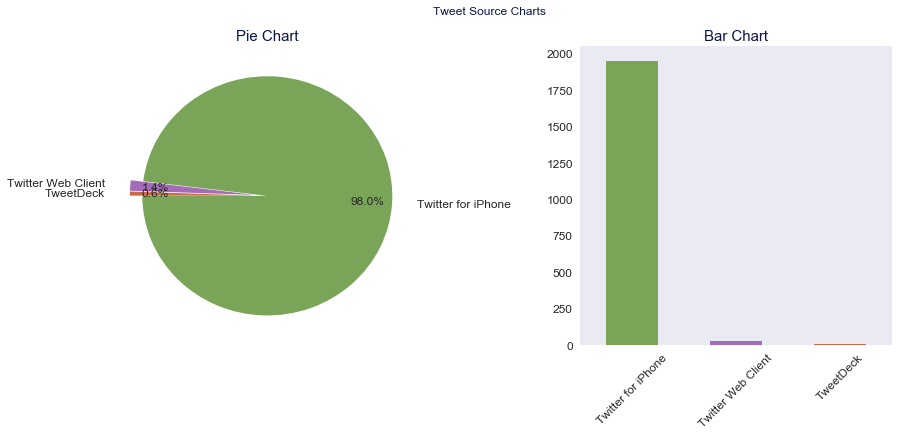

```python
colors = ["#7aa457","#a46cb7","#cb6a49"]

f, ax = plt.subplots(1, 2, figsize = (14, 5.5))
plt.subplots_adjust(wspace=0.5)

source_counts.plot(kind='pie',
                   ax = ax[0],
                   label='',
                   pctdistance=0.8,
                   labeldistance=1.2,
                   colors=colors,
                   autopct='%.1f%%',
                   explode=[0,.1,.1],
                   fontsize=12,
                   startangle=180)

source_counts.plot(kind='bar',ax = ax[1],rot=45,grid=False,color=colors,fontsize=12)

ax[0].set_title("Pie Chart",fontsize=15,color='#0B1746')
ax[1].set_title("Bar Chart",fontsize=15,color='#0B1746')

f.suptitle('Tweet Source Charts',color='#0B1746')

plt.savefig('1 Tweet Source Charts.png',dpi=400, bbox_inches='tight');
```

#### 小结

可以看出，推主tweet的主要方式是使用iphone手机客户端，占比高达98%，这是很好理解的，手机轻巧，方便外出携带，自带拍照上网功能，看到有趣的狗狗，随时拍照记录，即拍完可上传评分，十分便捷

### 哪种stage的狗狗最多？

```python
df_archive.stage.value_counts()
```

```
pupper          229
doggo            69
floof            35
puppo            28
doggo,pupper      4
pupper,doggo      2
doggo,puppo       1
Name: stage, dtype: int64
```

```python
# 创建stage的DF结构数据
df_stage = pd.DataFrame({'stage':df_archive.stage})

# 拆分有多种stage的行
stage_mult = df_stage[df_stage.stage.str.contains(',',na=False)].stage.str.split(',')
stage_1,stage_2 = stage_mult.str

# 只有一种stage的行
stage_0 = df_stage.stage[-df_stage.stage.str.contains(',',na=False)].dropna()

stage_list = list(stage_0.values) + list(stage_1.values) + list(stage_2.values)
stage_ser = pd.Series(stage_list)
```

```python
stage_counts =stage_ser.value_counts()
stage_counts
```

```
pupper    235
doggo      76
floof      35
puppo      29
dtype: int64
```

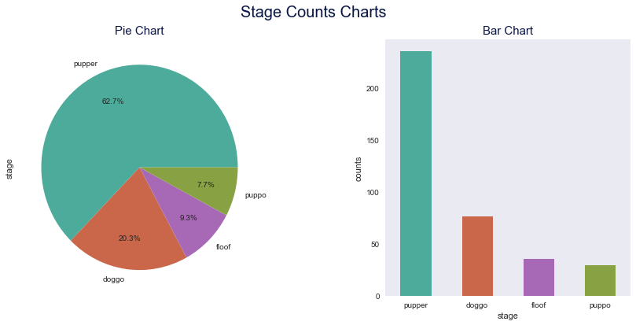

```python
colors = ["#4dab9b","#ca674a","#a768b5","#88a243"]

f, ax = plt.subplots(1, 2, figsize=(14,6))
plt.subplots_adjust(wspace=0.5)

stage_counts.plot(kind='pie',
                   ax=ax[0],
                   pctdistance=0.7,
                   autopct='%.1f%%',
                   colors=colors)
stage_counts.plot(kind='bar',
                   ax=ax[1],
                   grid=False,
                   color=colors,
                   rot=0)

ax[0].set_title("Pie Chart",fontsize=15,color='#0B1746')
ax[1].set_title("Bar Chart",fontsize=15,color='#0B1746')

ax[1].set_xlabel('stage')
ax[1].set_ylabel('counts')
ax[0].set_ylabel('stage')

f.suptitle('Stage Counts Charts',fontsize=20,color='#0B1746')

plt.savefig('2 Stage Counts Charts.png',dpi=400, bbox_inches='tight');
```

### 评分，喜欢和转发三者之间两两关系？

```python
# 创建评分列
df_archive['rating'] = df_archive.rating_numerator/df_archive.rating_denominator
```

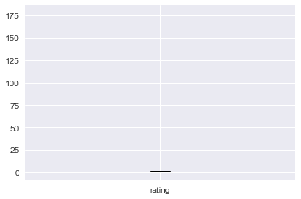

```python
# 直接绘制箱线图，会看到都压在一块
df_archive.rating.plot(kind='box');
```

```python
outlier_index = df_archive.rating_numerator.sort_values(ascending=False).index[0]
outlier_index
```

```
726
```

```python
# 去除在index = 726位置的异常值前后的对比图
df_archive_new = df_archive.loc[np.r_[0:outlier_index,(outlier_index+1):2115]]
pd.DataFrame({'before':df_archive.rating.describe(),
              'after':df_archive_new.rating.describe()},
              columns=['before','after'])
```

|  | before | after |
| --- | --- | --- |
| count | 1992.000000 | 1991.000000 |
| mean | 1.144266 | 1.055639 |
| std | 3.961497 | 0.216657 |
| min | 0.000000 | 0.000000 |
| 25% | 1.000000 | 1.000000 |
| 50% | 1.100000 | 1.100000 |
| 75% | 1.200000 | 1.200000 |
| max | 177.600000 | 1.400000 |

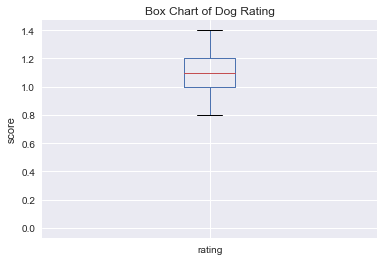

```python
df_archive_new.rating.plot(kind='box')
plt.ylabel('score')
plt.title('Box Chart of Dog Rating');
```

```python
df_archive_new_corr = df_archive_new[['rating','retweet_count','favorite_count']].corr(method='pearson')
df_archive_new_corr
```

|  | rating | retweet_count | favorite_count |
| --- | --- | --- | --- |
| rating | 1.000000 | 0.308543 | 0.411237 |
| retweet_count | 0.308543 | 1.000000 | 0.914948 |
| favorite_count | 0.411237 | 0.914948 | 1.000000 |

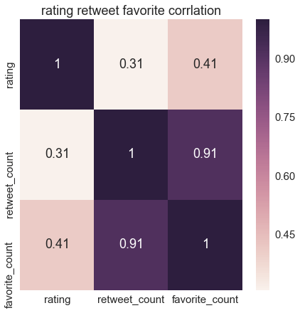

```python
sns.set(font_scale=1.5) # 字体大小设置
fig = plt.figure(figsize=(7,7)) # 图像区域大小
sns.heatmap(df_archive_new_corr, annot=True) # annot=True是为了在每个小方块中注明对应的（相关性）数值
plt.title('rating retweet favorite corrlation')

plt.savefig('3_1 rating retweet favorite corrlation.png',dpi=400, bbox_inches='tight');
```

```python
df_archive_new.info()
```

```
<class 'pandas.core.frame.DataFrame'>
Int64Index: 2114 entries, 0 to 2114
Data columns (total 16 columns):
tweet_id              1991 non-null float64
timestamp             1991 non-null object
source                1991 non-null object
text                  1991 non-null object
expanded_urls         1991 non-null object
rating_numerator      1991 non-null float64
rating_denominator    1991 non-null float64
retweet_count         1991 non-null float64
favorite_count        1991 non-null float64
stage                 368 non-null object
names                 1384 non-null object
jpg_url               1991 non-null object
img_num               1991 non-null float64
dog_type              1991 non-null object
confidence            1991 non-null float64
rating                1991 non-null float64
dtypes: float64(8), object(8)
memory usage: 280.8+ KB
```

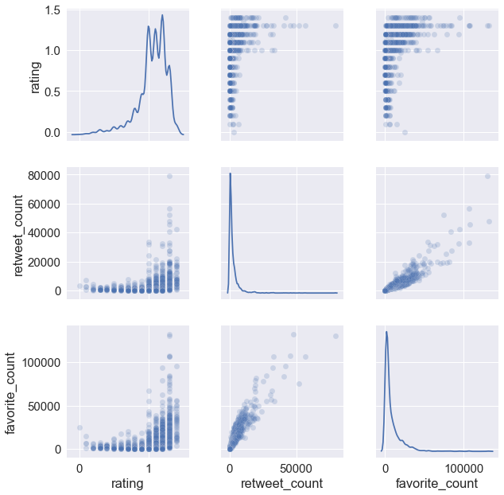

```python
# 绘制散点图
df_pair = df_archive_new[['rating','retweet_count','favorite_count']]
sns.pairplot(df_pair.dropna(), diag_kind='kde', size=3, plot_kws={'alpha':0.2})

plt.savefig('3_2 rating retweet favorite scatters.png',dpi=400, bbox_inches='tight');
```

```python
df_archive_new_corr
```

|  | rating | retweet_count | favorite_count |
| --- | --- | --- | --- |
| rating | 1.000000 | 0.308543 | 0.411237 |
| retweet_count | 0.308543 | 1.000000 | 0.914948 |
| favorite_count | 0.411237 | 0.914948 | 1.000000 |

#### 小结

- 从热力图或者散点图,可以看出，转发数和喜爱数是呈正相关的，两者的皮尔逊相关系数高达 0.91
  - 这个很好理解，因为一般喜爱的非敏感话题，大家更有可能会彼此分享到各自的圈子，让其扩散，而各自的圈子里的人，大多与自己喜好相同，继而被自己圈子的人喜爱和转发，而扩散之后，又可以被点赞和转发，接着循环如上。喜爱和转发两者的按钮设计的又十分靠近，方便快捷。让点赞和转发几乎同时发生。
- 评分（这里指分子/分母的比值）与 喜欢和转发数之间关系相关性虽然没有没有转发数和喜爱数之间的那么强烈，但是也是较高的，分别为 0.411237 和 0.308543

**评分与转发数的相关性较低原因，我的理解**

- 人与人之间的差异性和相似性造就了这个结果
  - 差异性，对狗狗评分的不同，这里其实可以通过查看一些tweet的评论发现，多数人的评分都各不一样。
    - 转发tweet的人跟推主的评分可能不一直，比如，同一张，图片，推主评分 12/10，那么有的人可能较为喜欢的14/10，低一些的10/10，都有可能
  - 相似性，对狗狗某些特征的有共同的喜爱，推主的评分代表了一部分人的评分，这里我称之为相似。
  - 具体点说：人们转发是出于自己的喜爱，而喜爱，是因人而异的
    - 这里做个思想实验，假设人们的喜爱同推主的一致，那么，根据上面喜爱和转发数的关系，相关系数高达0.91，再假设评分反应了推主的喜爱程度，那么可以推断出，评分越高，喜欢的程度就越高，转发的概率也就更高，也就表明，评分和转发相关性很强。现在只改变一个条件，假设人们的喜爱不大一致，那么，推主的评分高的话，只能代表推主的评分，不能代表全体人们内心的评分，反应在相关性上，比之前弱了些，也就是相关系数要更小些。

### 哪种品种的狗狗的评分次数较多

```python
top_20 = df_archive.dog_type.value_counts()[1:21]
top_20
```

```
Golden_Retriever             158
Labrador_Retriever           108
Pembroke                      95
Chihuahua                     91
Pug                           62
Toy_Poodle                    51
Chow                          48
Pomeranian                    42
Samoyed                       42
Malamute                      33
Chesapeake_Bay_Retriever      31
French_Bulldog                31
Cocker_Spaniel                30
Miniature_Pinscher            25
Eskimo_Dog                    22
Cardigan                      21
Staffordshire_Bullterrier     21
German_Shepherd               21
Shih-Tzu                      20
Siberian_Husky                20
Name: dog_type, dtype: int64
```

```python
top_20.sort_values()
```

```
Siberian_Husky                20
Shih-Tzu                      20
German_Shepherd               21
Staffordshire_Bullterrier     21
Cardigan                      21
Eskimo_Dog                    22
Miniature_Pinscher            25
Cocker_Spaniel                30
French_Bulldog                31
Chesapeake_Bay_Retriever      31
Malamute                      33
Pomeranian                    42
Samoyed                       42
Chow                          48
Toy_Poodle                    51
Pug                           62
Chihuahua                     91
Pembroke                      95
Labrador_Retriever           108
Golden_Retriever             158
Name: dog_type, dtype: int64
```

```python
colors_20 = ["#46c0be","#5e92cd","#b9a562","#c1616a","#dd84b4",
             "#66752a","#50a470","#964578","#9b5e2b","#e48c66",
             "#b085d2","#5969ca","#a5b440","#c43f3d","#d79b33",
             "#dd4072","#d250ad","#5ab74a","#d9592b","#9c57cb"]
```

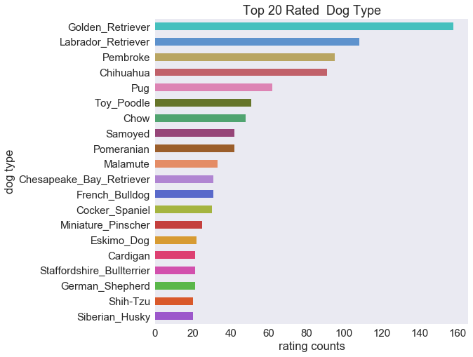

```python
top_20.sort_values().plot(kind='barh',grid=False,figsize=(8,8),color=colors_20[::-1])
plt.title('Top 20 Rated  Dog Type')
plt.xlabel('rating counts')
plt.ylabel('dog type')

plt.savefig('4_1 Top 20 Rated  Dog Type.png',dpi=400, bbox_inches='tight');
```

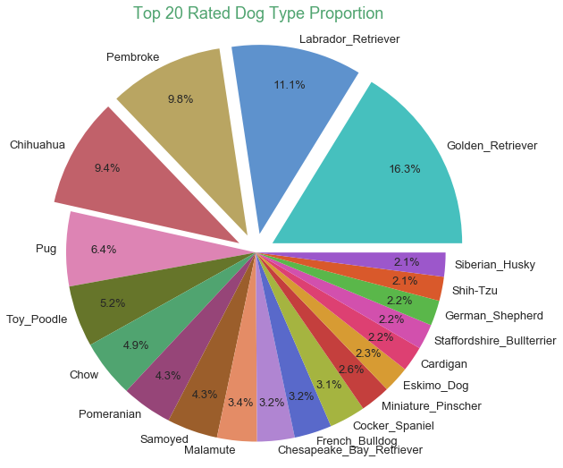

```python
top_20.plot(kind='pie',
            shadow=False, # 饼块是否带有阴影
            autopct='%.1f%%', # 百分比显示
            startangle=0, # 旋转角度
            labeldistance=1.05,# 距离中心多少距离，相对于半径而言
            colors=colors_20, # 使用的颜色
            label= '', # 设置为空字符，不让其显示
            explode=[0.1]*4+[0]*16, # 将一些饼图向外移动一些距离
            figsize=(9,9),  # 画布大小
            pctdistance=0.8, # 百分比距离中心多少距离，相对于半径来说
            fontsize=13)    # 字体大小，百分比，每个饼的label
plt.axis('equal')
plt.title('Top 20 Rated Dog Type Proportion', # 标题名
          loc='center', # 标题位置
          color='#50a470') # 标题颜色

plt.savefig('4_2 Top 20 Rated  Dog Type piechart.png',dpi=400, bbox_inches='tight');
```

```python
df_archive.dog_type.value_counts()[1:].describe()
```

```
count    113.000000
mean      14.920354
std       22.402225
min        1.000000
25%        4.000000
50%        8.000000
75%       16.000000
max      158.000000
Name: dog_type, dtype: float64
```

#### 小结

评分次数排名前四的分别为：Golden Retriever，Labrador_Retriever，Pembroke，Chihuahua,评分次数分别为158，108，95，91 而不同品种的狗狗评分次数的平均评分次数为 14.92，标准差为22.4，可以看出分布还是较为离散的。

我的理解是

- 可能推主更喜欢这些种类的狗狗，也可能推主遇见此类狗狗较多
- 还可能是，预测狗狗的程序，对这类狗狗更好预测，导致预测结果中，这类狗狗的占比较大

### 常见的狗狗名字

```python
df_archive.names.value_counts()[:10]
```

```
Charlie    11
Oliver     11
Cooper     10
Penny       9
Tucker      9
Lucy        9
Winston     8
Sadie       7
Lola        7
Daisy       7
Name: names, dtype: int64
```

```python
# 创建name的DF结构数据
df_name = pd.DataFrame({'name':df_archive.names})

# 拆分有多种name的行
name_mult = df_name[df_name.name.str.contains(',',na=False)].name.str.split(',')
name_1,name_2 = name_mult.str

# 只有一种name的行
name_0 = df_name.name[-df_name.name.str.contains(',',na=False)].dropna()

name_list = list(name_0.values) + list(name_1.values) + list(name_2.values)
name_ser = pd.Series(name_list)
```

```python
name_counts = name_ser.value_counts()
name_counts[:20]
```

```
Oliver     12
Charlie    12
Lucy       10
Cooper     10
Tucker      9
Penny       9
Daisy       8
Sadie       8
Winston     8
Lola        7
Toby        7
Bella       6
Stanley     6
Bo          6
Koda        6
Jax         6
Louis       5
Dave        5
Scout       5
Buddy       5
dtype: int64
```

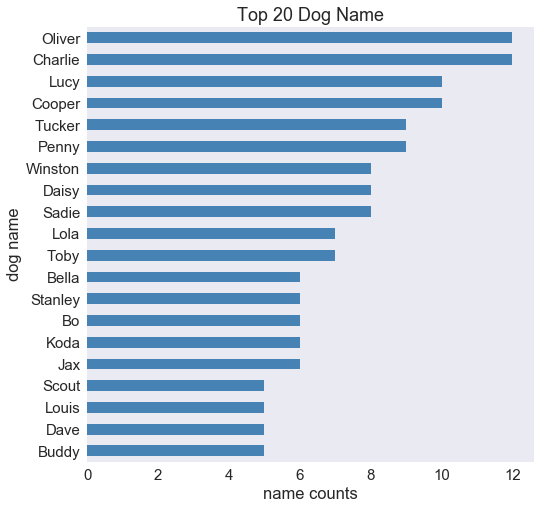

```python
name_counts[:20].sort_values().plot(kind='barh',grid=False,figsize=(8,8),color='steelblue')
plt.title('Top 20 Dog Name')
plt.xlabel('name counts')
plt.ylabel('dog name')

plt.savefig('5 Top 20 Dog Name.png',dpi=400, bbox_inches='tight');
```

```python
name_counts[:20]
```

```
Oliver     12
Charlie    12
Lucy       10
Cooper     10
Tucker      9
Penny       9
Daisy       8
Sadie       8
Winston     8
Lola        7
Toby        7
Bella       6
Stanley     6
Bo          6
Koda        6
Jax         6
Louis       5
Dave        5
Scout       5
Buddy       5
dtype: int64
```

#### 小结

常见的狗狗名字排序如上前四名（降序排序）分别为：Charlie, Oliver, Lucy 和 Cooper

### 狗狗名字几个字符的居多？

```python
name_length = [len(str(name)) for name in name_list]
name_length_counts = pd.Series(name_length).value_counts()
name_length_counts
```

```
5     398
6     312
4     298
7     211
3      78
8      68
9      26
2      12
10      6
12      2
14      1
11      1
dtype: int64
```

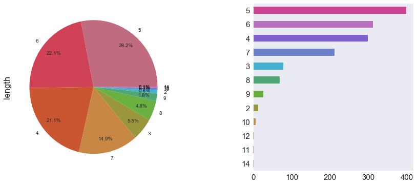

```python
# 我们看到，由于大于10的长度数据太少，导致饼状图中长度为11，12，14 的字体都重叠在一块
# 这里下面我会作一个处理，将长度大于 10 的数据合并至 10
# 合并后新建一个Series，其中index为length，值为对应的length计数，最后一个为 >10 的index
colors = \
["#c16b80",
"#d04256",
"#c95631",
"#c88744",
"#99963e",
"#69b040",
"#4fa774",
"#45b0cf",
"#6c81c9",
"#7e5fcf",
"#ba6ec0",
"#cd4391"]

f, ax = plt.subplots(1,2,figsize=(14,6))
plt.subplots_adjust(wspace=0.5)

name_length_counts.plot(kind='pie',
                        ax=ax[0],
                        autopct='%.1f%%',
                        colors=colors,
                        pctdistance=0.8,
                        label='length',
                        fontsize=10,
                        startangle=0,
                        labeldistance=1.1
                       )
name_length_counts.sort_values().plot(kind='barh',ax=ax[1],grid=False,color=colors);
```

```python
# 将大于等于 10 的长度个数合并至一个新的单独的series中
exceed_10 = pd.Series(name_length_counts[-4:].sum(),index=['>= 10'])
new_name_length_counts = name_length_counts.copy(deep=True)
new_name_length_counts = new_name_length_counts[:-4].append(exceed_10)
```

```python
new_name_length_counts
```

```
5        398
6        312
4        298
7        211
3         78
8         68
9         26
2         12
>= 10     10
dtype: int64
```

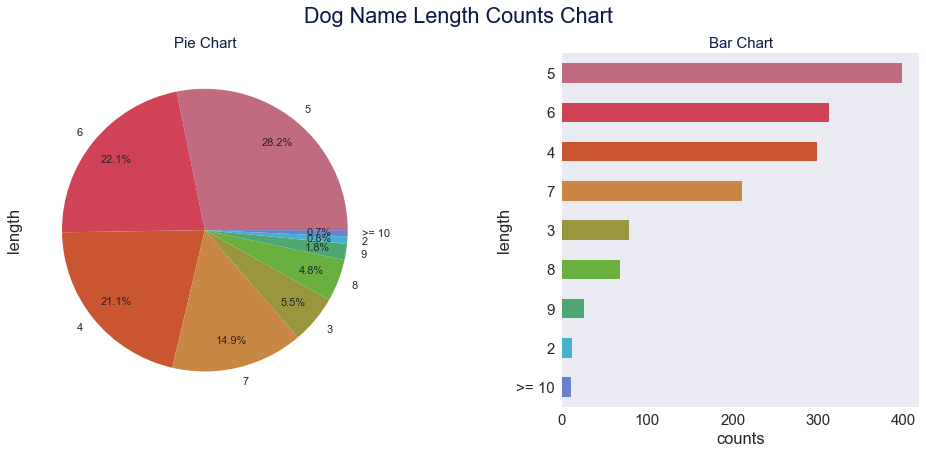

```python
# 修正后的狗狗名字长度计数图
colors = \
["#c16b80",
"#d04256",
"#c95631",
"#c88744",
"#99963e",
"#69b040",
"#4fa774",
"#45b0cf",
"#6c81c9"]

f, ax = plt.subplots(1,2,figsize=(16,6.5))
plt.subplots_adjust(wspace=0.5)

new_name_length_counts.plot(kind='pie',
                        ax=ax[0],
                        autopct='%.1f%%',
                        colors=colors,
                        pctdistance=0.8,
                        label='length',
                        fontsize=11,
                        startangle=0,
                        labeldistance=1.1
                       )
new_name_length_counts.sort_values().plot(kind='barh',ax=ax[1],grid=False,color=colors[::-1])

ax[0].set_title("Pie Chart",fontsize=15,color='#0B1746')
ax[1].set_title("Bar Chart",fontsize=15,color='#0B1746')

ax[1].set_xlabel('counts')
ax[1].set_ylabel('length')

f.suptitle('Dog Name Length Counts Chart',color='#0B1746')

plt.savefig('6_1 Dog Name Length Counts Chart.png',dpi=400, bbox_inches='tight');
```

```python
# 排名前四的名字长度占比
name_length_counts[:4].sum()/name_length_counts.sum()
```

```
0.8627034677990092
```

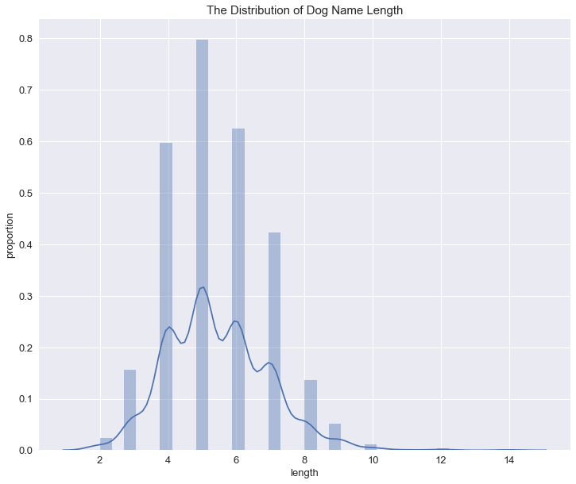

```python
# 狗狗名字长度分布图
f,ax = plt.subplots(figsize = (12,10))
ax = sns.distplot(name_length)
ax.tick_params(axis='y',labelsize=13)
ax.tick_params(axis='x',labelsize=13)
ax.set_title('The Distribution of Dog Name Length',fontsize=15)
ax.set_xlabel('length',fontsize=13)
ax.set_ylabel('proportion',fontsize=13)

plt.savefig('6_2 The Distribution of Dog Name Length.png',dpi=400, bbox_inches='tight');
```

```python
new_name_length_counts/sum(new_name_length_counts)
```

```
5        0.281670
6        0.220807
4        0.210899
7        0.149328
3        0.055202
8        0.048125
9        0.018401
2        0.008493
>= 10    0.007077
dtype: float64
```

```python
sum(new_name_length_counts[:4])/sum(new_name_length_counts)
```

```
0.86270346779900919
```

### 评分最高的狗狗

```python
df_archive.rating.sort_values(ascending=False)[:10]
```

```
726    177.6
162      1.4
324      1.4
332      1.4
399      1.4
36       1.4
113      1.4
153      1.4
571      1.4
49       1.4
Name: rating, dtype: float64
```

```python
df_archive.loc[726]
```

```
tweet_id                                             749981277374128128
timestamp                                           2016-07-04 15:00:45
source                                                        TweetDeck
text                  This is Atticus. He's quite simply America af....
expanded_urls         https://twitter.com/dog_rates/status/749981277...
rating_numerator                                                   1776
rating_denominator                                                   10
retweet_count                                                      2769
favorite_count                                                     5594
stage                                                               NaN
names                                                           Atticus
jpg_url                 https://pbs.twimg.com/media/CmgBZ7kWcAAlzFD.jpg
img_num                                                               1
dog_type                                                       NotFound
confidence                                                            0
rating                                                            177.6
Name: 726, dtype: object
```

tweet 对应网址： https://twitter.com/dog_rates/status/749981277374128128/photo/1

**本数据集最高评分的狗狗到底是什么样子?**

[figure not shown]

```python
df_archive.loc[726,'timestamp']
```

```
'2016-07-04 15:00:45'
```

#### 小结

- 最高评分原因
  - 发送tweet的当天是 7.4 ，是美国的独立日，具有特别意义
  - 1776年7月4日，美利坚合众国在费城发表独立宣言，正式宣布独立
  - 这里我猜推主的此次评分分子1776 就来源于此(1776年7月4日)
  - 狗狗图片中的背景，也是带着美国的国旗

### 不同种类的狗狗的平均评分

```python
df_archive.info()
```

```
<class 'pandas.core.frame.DataFrame'>
RangeIndex: 1992 entries, 0 to 1991
Data columns (total 16 columns):
tweet_id              1992 non-null int64
timestamp             1992 non-null object
source                1992 non-null object
text                  1992 non-null object
expanded_urls         1992 non-null object
rating_numerator      1992 non-null float64
rating_denominator    1992 non-null float64
retweet_count         1992 non-null float64
favorite_count        1992 non-null float64
stage                 368 non-null object
names                 1385 non-null object
jpg_url               1992 non-null object
img_num               1992 non-null int64
dog_type              1992 non-null object
confidence            1992 non-null float64
rating                1992 non-null float64
dtypes: float64(6), int64(2), object(8)
memory usage: 249.1+ KB
```

```python
type_rating = df_archive.groupby('dog_type').rating.mean().sort_values(ascending=False)
type_rating[:10]
```

```
dog_type
NotFound                1.482026
Bouvier_Des_Flandres    1.300000
Saluki                  1.250000
Briard                  1.233333
Tibetan_Mastiff         1.225000
Border_Terrier          1.214286
Silky_Terrier           1.200000
Standard_Schnauzer      1.200000
Gordon_Setter           1.175000
Irish_Setter            1.175000
Name: rating, dtype: float64
```

```python
type_rating.sort_values(ascending=False)[:31]
```

```
dog_type
NotFound                      1.482026
Bouvier_Des_Flandres          1.300000
Saluki                        1.250000
Briard                        1.233333
Tibetan_Mastiff               1.225000
Border_Terrier                1.214286
Silky_Terrier                 1.200000
Standard_Schnauzer            1.200000
Gordon_Setter                 1.175000
Irish_Setter                  1.175000
Samoyed                       1.169048
Golden_Retriever              1.162975
Wire-Haired_Fox_Terrier       1.150000
Giant_Schnauzer               1.150000
Great_Pyrenees                1.146667
Norfolk_Terrier               1.142857
Chow                          1.141667
Eskimo_Dog                    1.140909
Pembroke                      1.138947
Doberman                      1.133333
Cocker_Spaniel                1.133333
Greater_Swiss_Mountain_Dog    1.133333
Irish_Water_Spaniel           1.133333
Leonberg                      1.133333
Kelpie                        1.130769
Bernese_Mountain_Dog          1.127273
Clumber                       1.127000
Siberian_Husky                1.125000
French_Bulldog                1.119355
Labrador_Retriever            1.118519
Cardigan                      1.114286
Name: rating, dtype: float64
```

```python
df_archive.describe().rating
```

```
count    1992.000000
mean        1.144266
std         3.961497
min         0.000000
25%         1.000000
50%         1.100000
75%         1.200000
max       177.600000
Name: rating, dtype: float64
```

```python
# 注意：这里我需要排除掉最高评分狗狗的干扰，
# 因为该狗狗的评分为 177.6，而其他狗狗的评分中位数为1.1，相差两个数量级之多
# 还好，这里并未识别出来该狗狗的品种
df_archive.loc[726][['dog_type','rating']]
```

```
dog_type    NotFound
rating         177.6
Name: 726, dtype: object
```

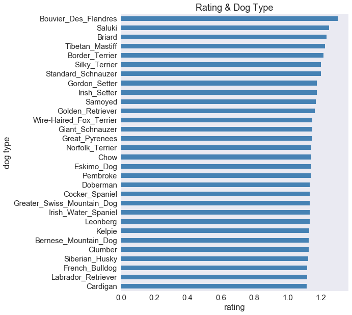

```python
# [-31:-1] 表示的是去掉最后一个，NotFound （未识别出狗狗），再取 30 个数据
type_rating.sort_values()[-31:-1].plot(kind='barh',grid=False,figsize=(8,10),color='steelblue')
plt.xlabel('rating')
plt.ylabel('dog type')
plt.title('Rating & Dog Type');
```

```python
t30_type_rating = type_rating.sort_values(ascending=False)[1:31]
t30_type_rating
```

```
dog_type
Bouvier_Des_Flandres          1.300000
Saluki                        1.250000
Briard                        1.233333
Tibetan_Mastiff               1.225000
Border_Terrier                1.214286
Silky_Terrier                 1.200000
Standard_Schnauzer            1.200000
Gordon_Setter                 1.175000
Irish_Setter                  1.175000
Samoyed                       1.169048
Golden_Retriever              1.162975
Wire-Haired_Fox_Terrier       1.150000
Giant_Schnauzer               1.150000
Great_Pyrenees                1.146667
Norfolk_Terrier               1.142857
Chow                          1.141667
Eskimo_Dog                    1.140909
Pembroke                      1.138947
Doberman                      1.133333
Cocker_Spaniel                1.133333
Greater_Swiss_Mountain_Dog    1.133333
Irish_Water_Spaniel           1.133333
Leonberg                      1.133333
Kelpie                        1.130769
Bernese_Mountain_Dog          1.127273
Clumber                       1.127000
Siberian_Husky                1.125000
French_Bulldog                1.119355
Labrador_Retriever            1.118519
Cardigan                      1.114286
Name: rating, dtype: float64
```

```python
t30_type_dog_counts = df_archive.dog_type.value_counts()[t30_type_rating.index]
t30_type_dog_counts
```

```
dog_type
Bouvier_Des_Flandres            1
Saluki                          4
Briard                          3
Tibetan_Mastiff                 4
Border_Terrier                  7
Silky_Terrier                   1
Standard_Schnauzer              1
Gordon_Setter                   4
Irish_Setter                    4
Samoyed                        42
Golden_Retriever              158
Wire-Haired_Fox_Terrier         2
Giant_Schnauzer                 4
Great_Pyrenees                 15
Norfolk_Terrier                 7
Chow                           48
Eskimo_Dog                     22
Pembroke                       95
Doberman                        9
Cocker_Spaniel                 30
Greater_Swiss_Mountain_Dog      3
Irish_Water_Spaniel             3
Leonberg                        3
Kelpie                         13
Bernese_Mountain_Dog           11
Clumber                         1
Siberian_Husky                 20
French_Bulldog                 31
Labrador_Retriever            108
Cardigan                       21
Name: dog_type, dtype: int64
```

```python
df_type_rating = pd.DataFrame({'counts':t30_type_dog_counts.values,
                               'rating':t30_type_rating.values},
                               index=t30_type_rating.index)
df_type_rating
```

| dog_type | counts | rating |
| --- | --- | --- |
| Bouvier_Des_Flandres | 1 | 1.300000 |
| Saluki | 4 | 1.250000 |
| Briard | 3 | 1.233333 |
| Tibetan_Mastiff | 4 | 1.225000 |
| Border_Terrier | 7 | 1.214286 |
| Silky_Terrier | 1 | 1.200000 |
| Standard_Schnauzer | 1 | 1.200000 |
| Gordon_Setter | 4 | 1.175000 |
| Irish_Setter | 4 | 1.175000 |
| Samoyed | 42 | 1.169048 |
| Golden_Retriever | 158 | 1.162975 |
| Wire-Haired_Fox_Terrier | 2 | 1.150000 |
| Giant_Schnauzer | 4 | 1.150000 |
| Great_Pyrenees | 15 | 1.146667 |
| Norfolk_Terrier | 7 | 1.142857 |
| Chow | 48 | 1.141667 |
| Eskimo_Dog | 22 | 1.140909 |
| Pembroke | 95 | 1.138947 |
| Doberman | 9 | 1.133333 |
| Cocker_Spaniel | 30 | 1.133333 |
| Greater_Swiss_Mountain_Dog | 3 | 1.133333 |
| Irish_Water_Spaniel | 3 | 1.133333 |
| Leonberg | 3 | 1.133333 |
| Kelpie | 13 | 1.130769 |
| Bernese_Mountain_Dog | 11 | 1.127273 |
| Clumber | 1 | 1.127000 |
| Siberian_Husky | 20 | 1.125000 |
| French_Bulldog | 31 | 1.119355 |
| Labrador_Retriever | 108 | 1.118519 |
| Cardigan | 21 | 1.114286 |

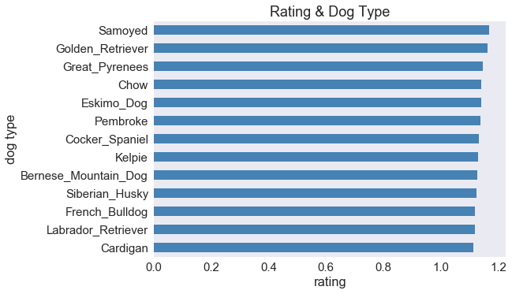

```python
# 考虑到某些狗狗参与评分的数据量太少，不能反应出该数据对应的平均值
# 这里筛选出评分次数超过 10 的数据

df_type_rating[df_type_rating.counts > 10].rating.sort_values().plot(kind='barh',color='steelblue',grid=False)
plt.xlabel('rating')
plt.ylabel('dog type')
plt.title('Rating & Dog Type')

plt.savefig('8 Rating & Dog Type.png',dpi=400, bbox_inches='tight');
```

```python
df_type_rating[df_type_rating.counts > 10]
```

| dog_type | counts | rating |
| --- | --- | --- |
| Samoyed | 42 | 1.169048 |
| Golden_Retriever | 158 | 1.162975 |
| Great_Pyrenees | 15 | 1.146667 |
| Chow | 48 | 1.141667 |
| Eskimo_Dog | 22 | 1.140909 |
| Pembroke | 95 | 1.138947 |
| Cocker_Spaniel | 30 | 1.133333 |
| Kelpie | 13 | 1.130769 |
| Bernese_Mountain_Dog | 11 | 1.127273 |
| Siberian_Husky | 20 | 1.125000 |
| French_Bulldog | 31 | 1.119355 |
| Labrador_Retriever | 108 | 1.118519 |
| Cardigan | 21 | 1.114286 |

```python
df_type_rating[df_type_rating.counts > 10].rating.describe()
```

```
count    13.000000
mean      1.136057
std       0.016543
min       1.114286
25%       1.125000
50%       1.133333
75%       1.141667
max       1.169048
Name: rating, dtype: float64
```

#### 小结

在评分分值排名前30的狗狗种类中，评分数量>10的评分中，只有13个品种入围

这13个品种的狗狗平均评分的偏差为0.016543，差别十分细微，平均评分的均值为1.136

平均评分排名前三由大到小排列

- 狗狗品种分别为 Samoyed，Golden_Retriever，Great_Pyrenees
- 平均评分分别为 1.169048，1.162975，1.146667

# 得出结论

## 推主哪一类客户端使用较多

可以看出，推主tweet的主要方式是使用iphone手机客户端，占比高达98%，这是很好理解的，手机轻巧，方便外出携带，自带拍照上网功能，看到有趣的狗狗，随时拍照记录，即拍完可上传评分，十分便捷

## 评分，喜欢和转发三者之间两两关系？

- 从热力图或者散点图,可以看出，转发数和喜爱数是呈正相关的，两者的皮尔逊相关系数高达 0.91
  - 这个很好理解，因为一般喜爱的非敏感话题，大家更有可能会彼此分享到各自的圈子，让其扩散，而各自的圈子里的人，大多与自己喜好相同，继而被自己圈子的人喜爱和转发，而扩散之后，又可以被点赞和转发，接着循环如上。喜爱和转发两者的按钮设计的又十分靠近，方便快捷。让点赞和转发几乎同时发生。
- 评分（这里指分子/分母的比值）与 喜欢和转发数之间关系相关性虽然没有没有转发数和喜爱数之间的那么强烈，但是也是较高的，分别为 0.411237 和 0.308543

**评分与转发数的相关性较低原因，我的理解如下**

- 人与人之间的差异性和相似性造就了这个结果
  - 差异性，对狗狗评分的不同，这里其实可以通过查看一些tweet的评论发现，多数人的评分都各不一样。
    - 转发tweet的人跟推主的评分可能不一直，比如，同一张，图片，推主评分 12/10，那么有的人可能较为喜欢的14/10，低一些的10/10，都有可能
  - 相似性，对狗狗某些特征的有共同的喜爱，推主的评分代表了一部分人的评分，这里我称之为相似。
  - 具体点说：人们转发是出于自己的喜爱，而喜爱，是因人而异的
    - 这里做个思想实验，假设人们的喜爱同推主的一致，那么，根据上面喜爱和转发数的关系，相关系数高达0.91，再假设评分反应了推主的喜爱程度，那么可以推断出，评分越高，喜欢的程度就越高，转发的概率也就更高，也就表明，评分和转发相关性很强。现在只改变一个条件，假设人们的喜爱不大一致，那么，推主的评分高的话，只能代表推主的评分，不能代表全体人们内心的评分，反应在相关性上，比之前弱了些，也就是相关系数要更小些。

## 哪种品种的狗狗的评分次数较多

评分次数排名前四的分别为：Golden Retriever，Labrador_Retriever，Pembroke，Chihuahua,评分次数分别为158，108，95，91 而不同品种的狗狗评分次数的平均评分次数为 14.92，标准差为22.4，可以看出分布还是较为离散的。

我的理解是

- 可能推主更喜欢这些种类的狗狗，也可能推主遇见此类狗狗较多
- 还可能是，预测狗狗的程序，对这类狗狗更好预测，导致预测结果中，这类狗狗的占比较大

## 常见的狗狗名字

常见的狗狗名字排序如上前四名（降序排序）分别为：Charlie, Oliver, Cooper 和 Lucy

## 评分最高的狗狗？

- 最高评分原因
  - 发送tweet的当天是 7.4 ，是美国的独立日，具有特别意义
  - 1776年7月4日，美利坚合众国在费城发表独立宣言，正式宣布独立
  - 这里我猜推主的此次评分分子1776 就来源于此(1776年7月4日)
  - 狗狗图片中的背景，也是带着美国的国旗

## 不同种类的狗狗的平均评分

在评分分值排名前30的狗狗种类中，评分数量>10的评分中，只有13个品种入围

这13个品种的狗狗平均评分的偏差为0.016543，差别十分细微，平均评分的均值为1.136

平均评分排名前三由大到小排列

- 狗狗品种分别为 Samoyed，Golden_Retriever，Great_Pyrenees
- 平均评分分别为 1.169048，1.162975，1.146667

# 反思

**不足之处如下**

#### 数据清洗中，狗狗名字的提取，并没有完全覆盖

#### 狗狗stage的提取，可能出现错误

#### 好多数据并没有完全探索

#### 不能保证预测狗狗品种的数据中的预测结果是完全正确

#### 自身经验有限，对数据的解读可能带有错误

# 参考资料

**网址**

[python画分布、密度等图形](https://blog.csdn.net/jinruoyanxu/article/details/53390943)

[Seaborn入门系列(一)——kdeplot和distplot](https://zhuanlan.zhihu.com/p/33977558)

[Seaborn-05-Pairplot多变量图](https://www.jianshu.com/p/6e18d21a4cad)

**书籍**

利用python进行数据分析